# HW3

Group 8

28 May 2024

Group :

Lisa Bensousan - 346462534 - lisa.bensoussan@mail.huji.ac.il  
Dan Levy - 346453202 - dan.levy5@mail.huji.ac.il  
Emmanuelle Fareau - 342687233 - emmanuel.fareau@mail.huji.ac.il

### Libraries used :

```r
library(data.table)
library(ggplot2)
library('tictoc')
library(stringr)
library (tidyverse)
library(stringr)
library(tidyr)
```

### Paths and Data :

We are loading the data in our R file.

```r
load("/Users/lisabensoussan/Desktop/Lab3/chr1_line.rda")

reads_file <- "/Users/lisabensoussan/Desktop/Lab3/TCGA-13-0723-01A_lib1_all_chr1.forward"
chr1_reads = fread(reads_file)

colnames(chr1_reads) = c("Chrom","Loc","FragLen")
head(chr1_reads)
```

```
##    Chrom   Loc FragLen
##    <int> <int>   <int>
## 1:     1    28     153
## 2:     1    35     184
## 3:     1    35     177
## 4:     1    36     186
## 5:     1    37       0
## 6:     1    37     242
```

```r
#load("/Users/Emmanuelle Fareau/Documents/Cours 2023-2024    (annee 4)/Maabada/chr1_line.rda")
```

## Introduction :

In this analysis, we examine DNA sequencing data to evaluate the alignment coverage of reads across a specified region of the chromosome. Our goal is to compare the observed coverage distribution with a theoretical Poisson distribution, which assumes random distribution of reads. This comparison will help us determine if the sequencing reads follow a random pattern, a common assumption in next-generation sequencing (NGS) analysis. By utilizing statistical tests, we aim to verify the validity of this assumption.

## Part A :

### Question א :

We want to calculate the average coverage in the same interval that we chose in lab 2. Here we want to calculate the expected distribution with the Poisson model and compare the expected distribution and the distribution obtained from the data in a table.

```r
beg_region <- 1
end_region <- 10000000
N <- end_region - beg_region + 1  # Total number of positions in the region of interest
read_starts <- rep(0, N)

# Compute coverage based on read locations

filtered_reads <- chr1_reads[Loc >= beg_region & Loc <= end_region, .(Loc)]
for (r in filtered_reads$Loc) {
    read_starts[r - beg_region + 1] <- read_starts[r - beg_region + 1] + 1
}

coverage_data <- data.frame(Position = beg_region:end_region, ReadStarts = read_starts)
coverage <- read_starts  # Define coverage as read_starts for further analysis
average_coverage <- mean(coverage)
cat("Average coverage from 1 to 1e+06 is:", average_coverage, "\n")
```

[output not shown]

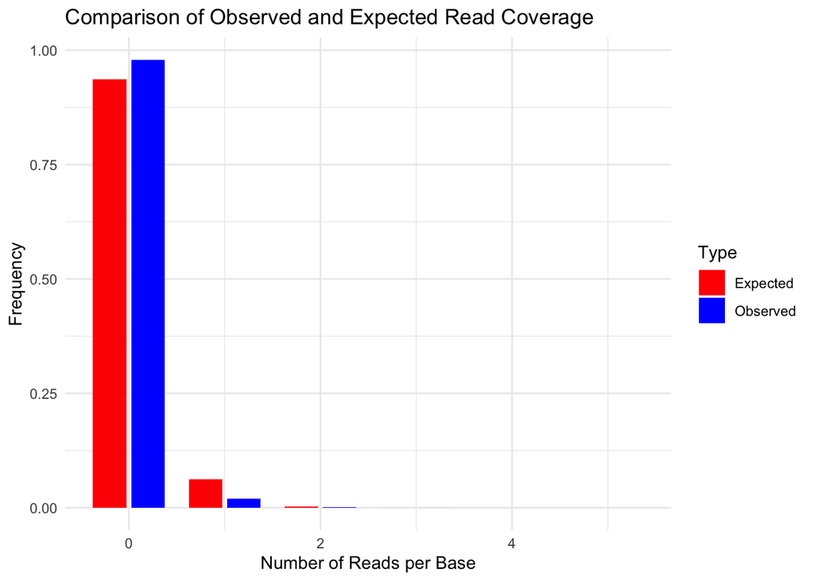

```r
# Expected Poisson distribution based on the computed average coverage
lambda <- average_coverage
expected_poisson <- dpois(0:5, lambda)

observed_freq <- table(factor(coverage[1:min(1000000, length(coverage))], levels = 0:5))

total_positions <- min(1000000, length(coverage))
observed_percentage <- as.numeric(observed_freq) / total_positions

coverage_data <- data.frame(
  Coverage = 0:5,
  Observed = observed_percentage,
  Expected = expected_poisson
)

coverage_data_long <- pivot_longer(coverage_data, cols = c("Observed", "Expected"), names_to = "Type", values_to = "Frequency")

ggplot(coverage_data_long, aes(x = Coverage, y = Frequency, fill = Type)) +
  geom_bar(stat = "identity", position = position_dodge(width = 0.8), width = 0.7) +
  scale_fill_manual(values = c("Observed" = "blue", "Expected" = "red")) +
  labs(title = "Comparison of Observed and Expected Read Coverage",
       x = "Number of Reads per Base", y = "Frequency") +
  theme_minimal()
```

```r
expected_poisson_full <- dpois(0:max(coverage), lambda)
observed_freq_full <- table(factor(coverage, levels = 0:max(coverage)))

expected_poisson_full <- expected_poisson_full / sum(expected_poisson_full)

comparison_table <- data.frame(
  Intervals = c("0-5", ">5"),
  Expected_Poisson = c(sum(expected_poisson_full[1:6]), sum(expected_poisson_full[7:length(expected_poisson_full)])),
  Observed_Data = c(sum(observed_freq_full[1:6]), sum(observed_freq_full[7:length(observed_freq_full)]))
)

total_positions <- sum(observed_freq_full)
comparison_table$Observed_Data <- comparison_table$Observed_Data / total_positions

print(comparison_table)
```

```
##   Intervals Expected_Poisson Observed_Data
## 1       0-5     1.000000e+00     0.9999871
## 2        >5     1.114547e-10     0.0000129
```

### Question ב :

We want to sum the fragments for each cell We use cell size of 10 000.

```r
setDT(chr1_reads)

cell_size <- 10000

chr1_data <- chr1_reads[Chrom == 1]

chr1_data[, Cell := floor((Loc - 1) / cell_size) + 1]

# Aggregate to count the number of fragments per cell
fragment_counts_per_cell <- chr1_data[, .(FragmentCount = .N), by = Cell]

# Sort results by Cell
fragment_counts_per_cell <- fragment_counts_per_cell[order(Cell)]

print(fragment_counts_per_cell)
```

```
##         Cell FragmentCount
##        <num>         <int>
##     1:     1           363
##     2:     2            36
##     3:     3            22
##     4:     4            17
##     5:     5            58
##    ---
## 22489: 24716           549
## 22490: 24717           454
## 22491: 24718           538
## 22492: 24719           470
## 22493: 24720           157
```

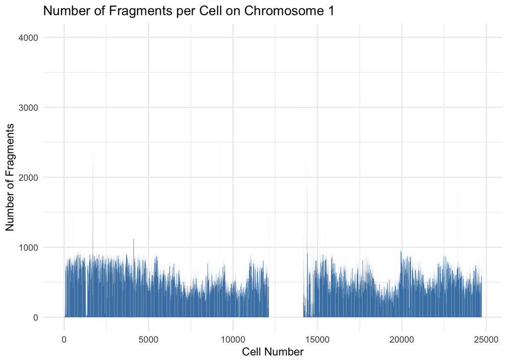

```r
ggplot(fragment_counts_per_cell, aes(x = Cell, y = FragmentCount)) +
  geom_bar(stat = "identity", fill = "steelblue") +
  labs(title = "Number of Fragments per Cell on Chromosome 1",
       x = "Cell Number",
       y = "Number of Fragments") +
  theme_minimal() +
  ylim(0, 4000)
```

#### a.

We first compute the center and dispersion of the observed data using median and IQR, and compare these to the theoretical expectations of a Poisson distribution.

```r
cell_size <- 10000

chr1_data <- chr1_reads[Chrom == 1]

# Aggregate fragment counts per cell
chr1_data[, Cell := floor((Loc - 1) / cell_size) + 1]
fragment_counts_per_cell <- chr1_data[, .N, by = Cell]


observed_median <- median(fragment_counts_per_cell$N)
observed_iqr <- IQR(fragment_counts_per_cell$N)


lambda <- mean(fragment_counts_per_cell$N)
expected_median <- lambda
expected_iqr <- qpois(0.75, lambda) - qpois(0.25, lambda)

cat("Observed Median:", observed_median, "\n")
```

```
## Observed Median: 511
```

```r
cat("Observed IQR:", observed_iqr, "\n")
```

```
## Observed IQR: 270
```

```r
cat("Expected Median (Poisson):", expected_median, "\n")
```

```
## Expected Median (Poisson): 528.1539
```

```r
cat("Expected IQR (Poisson):", expected_iqr, "\n")
```

```
## Expected IQR (Poisson): 31
```

1. Median Comparison:
- Observed Median: 511
- Expected Median (Poisson): 528.1539
- The observed median is slightly lower than the expected median but relatively close, indicating that the central tendency of your data is not far off from what a Poisson distribution would predict. This suggests a decent fit at the center of the distribution.

```
2.  Interquartile Range (IQR) Comparison:
```

- Observed IQR: 270
- Expected IQR (Poisson): 31
- The observed IQR is substantially larger than the expected IQR from the Poisson model.

This discrepancy indicates a much greater variability in the data than what the Poisson distribution accounts for. Such a wide IQR compared to the model suggests that the data may be overdispersed relative to a Poisson distribution, which assumes the mean equals the variance.

###b.

Then, we plote the histogram of the observed data and overlay the expected Poisson distribution. The histogram of the observed data does not looks like the the expected Poisson distribution.

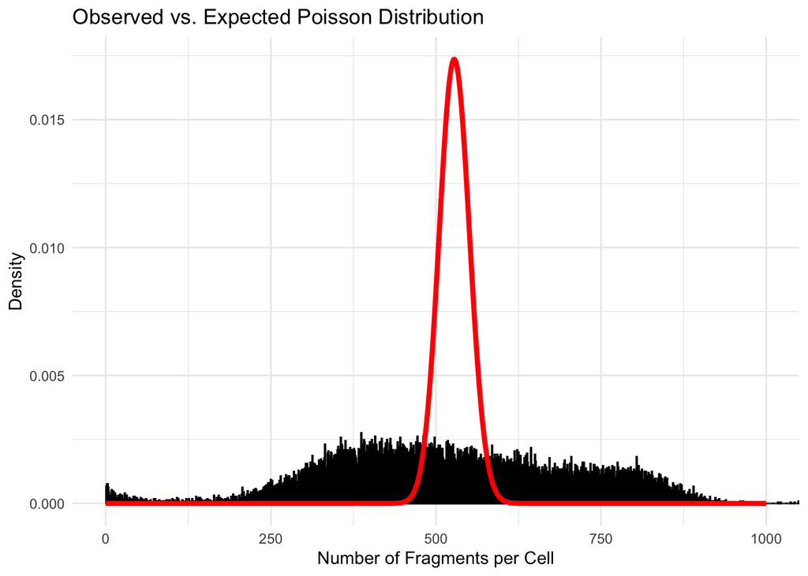

```r
expected_poisson <- dpois(0:1000, lambda)
expected_data <- data.frame(Count = 0:1000, Frequency = expected_poisson)


ggplot() +
  geom_histogram(data = fragment_counts_per_cell, aes(x = N, y = ..density..),
                 binwidth = 1, fill = "skyblue", color = "black", alpha = 0.7) +
  geom_line(data = expected_data, aes(x = Count, y = Frequency, group = 1),
            color = "red", size = 1.5) +
  labs(title = "Observed vs. Expected Poisson Distribution",
       x = "Number of Fragments per Cell",
       y = "Density") +
  theme_minimal() +
  guides(fill = guide_legend(title = "Legend"), color = guide_legend(title = "Legend")) +
  coord_cartesian(xlim = c(0, 1000))  # Set x-axis limits from 0 to 1000
```

- The observed distribution shows a wide spread with a peak around 500 fragments per cell, but also significant frequencies extending towards both lower and higher fragment counts.
- The Poisson distribution curve, which should ideally fit the data if the event occurrences were completely random and uniformly distributed, is sharply peaked around its mean and rapidly tapers off. This theoretical curve does not capture the breadth of the observed data.

This visual comparison provides strong evidence that the observed data does not follow a uniform Poisson process, suggesting complexities in the underlying biological or technical factors influencing the distribution of fragment counts.

###c.

To quantitatively assess the difference between the observed and expected distributions, you can use the Kullback-Leibler divergence, a common measure of how one probability distribution diverges from a second, expected probability distribution.

```r
epsilon <- 1e-10
observed_probs <- observed_freq / sum(observed_freq) + epsilon

expected_probs <- expected_poisson[1:length(observed_probs)] + epsilon

# Calculate Kullback-Leibler divergence :

kl_divergence <- sum(observed_probs * log(observed_probs / expected_probs))

cat("Kullback-Leibler Divergence:", kl_divergence, "\n")
```

```
## Kullback-Leibler Divergence: 22.91928
```

The Kullback-Leibler Divergence 22.9192813 suggests a considerable discrepancy between the expected and observed distributions. This value implies that using the Poisson model to represent the data would lead to substantial information loss, indicating that the Poisson model may not be an adequate fit.

## Part B :

### Question ב :

### Question a :

We study the data over an interval of 50 million.

```r
your_matrix <- as.matrix(chr1_line)
char_vector <- as.vector(your_matrix)

first_50000000 <- char_vector[1:50000000]

interval_size <- 5000

cg_counts <- numeric()

for (i in seq(1, 50000000, by = interval_size)) {
  interval <- first_50000000[i:min(i + interval_size - 1, 50000000)]
  interval_string <- paste(interval, collapse = "")
  cg_count <- str_count(interval_string, "GC")
  cg_counts <- c(cg_counts, cg_count)
}

print(cg_counts)
```

[output not shown]

[output cut: 541 more lines]

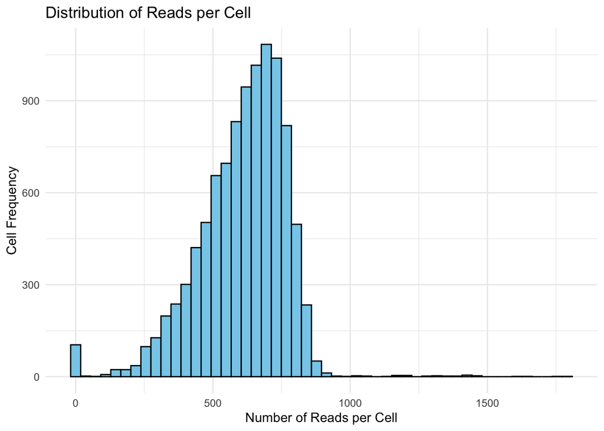

```r
cell_size <- 5000
end_region <- 50000000
num_cells <- ceiling(end_region / cell_size)

for (i in 1:nrow(chr1_reads)) {
  cell_index <- ceiling(chr1_reads$Loc[i] / cell_size)
  if (cell_index <= num_cells) {
    cg_counts[cell_index] <- cg_counts[cell_index] + 1
  }
}


coverage_data <- data.frame(Cell = 1:num_cells, CG_Count = cg_counts)

ggplot(coverage_data, aes(x = CG_Count)) +
  geom_histogram(bins = 50, fill = 'skyblue', color = 'black') +
  labs(title = "Distribution of Reads per Cell",
       x = "Number of Reads per Cell",
       y = "Cell Frequency") +
  theme_minimal()
```

### Question b :

In this question, we want to sum the number of reads in each cell.

```r
count_fragment_starts <- function(data, chrom_number, start_range, end_range) {
  relevant_data <- data[Chrom == chrom_number & Loc >= start_range & Loc <= end_range,]
  start_counts <- integer(end_range - start_range + 1)
  names(start_counts) <- as.character(start_range:end_range)

  starts <- table(relevant_data$Loc)

  start_positions <- as.character(names(starts))
  start_counts[start_positions] <- as.integer(starts)

  return(start_counts)
}



small_range_counts <- count_fragment_starts(chr1_reads, 1, 1, 50000000)
# print(small_range_counts)



calculate_chunk_sums <- function(vec, chunk_size) {
  chunks <- split(vec, rep(1:ceiling(length(vec) / chunk_size), each = chunk_size, length.out = length(vec)))
  chunk_sums <- sapply(chunks, sum)

  return(chunk_sums)
}


chunk_size <- 5000
result_vector <- calculate_chunk_sums(small_range_counts, chunk_size)

cat("Length of the result vector:", length(result_vector), "\n")
```

```
## Length of the result vector: 10000
```

```r
print(result_vector)
```

[output not shown]

[output cut: 1525 more lines]

We found the number of reads by interval of lenght 5 000.

### Question c :

In this question, we want to find the correlation coefficient between our two vectors : vectors of CG count and the vector of number of reads.

```r
cg_vector <- as.vector(cg_counts)
correlation_coefficient <- cor(cg_vector, result_vector)

print(correlation_coefficient)
```

```
## [1] 0.9251188
```

The correlation coefficient is positive. Thanks to our result, we can see that they have correlation because the correlation coefficient is closer to 1 than 0.

### Question d :

We want to graph the number of CGs in relation to the number of reads and create a regret line to see if there is a correlation between the two.

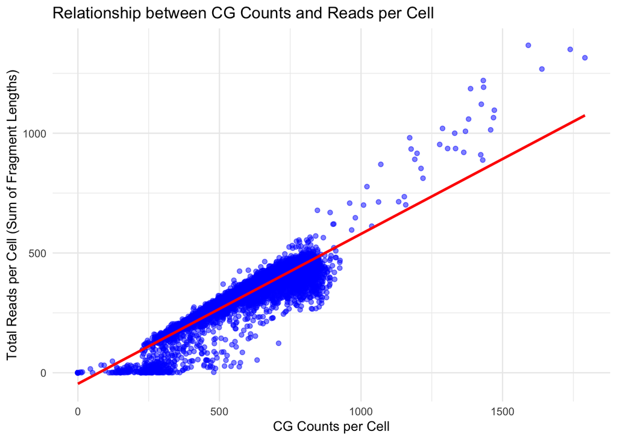

```r
dt <- data.frame(cg_counts, result_vector)

ggplot(dt, aes(x = cg_counts, y = result_vector)) +
  geom_point(color = "blue", alpha = 0.5) +
  geom_smooth(method = "lm", color = "red") +
  labs(title = "Relationship between CG Counts and Reads per Cell",
       x = "CG Counts per Cell",
       y = "Total Reads per Cell (Sum of Fragment Lengths)") +
  theme_minimal()
```

We can see a scatterplot gathering around the regression line which is ascending as well as several outliers above the regression line and many outliers below.

It is different of plot of Dohm because in the two plot, we can see a clearly ascending trend but in our plot we have much more outliers.

### Question e :

In both parts, we used statistic concepts to analyse our datasets and to see if there is a specific pattern about the results.